# Lexis Surfaces

Tim Riffe

7/14/2021

# Introduction

This tutorial gives code for some basic diagnostic Lexis surfaces. We’ll use HMD data as an example. In general, we’ll want to start from a tidy data format with columns for year, age, and the variable of interest. I’ll also give a code snippet for transforming a data matrix into such a tidy format.

# Example data

This is how I got the data, FYI, but you can load the data straight from this repository in the following code chunk.

```r
library(HMDHFDplus)
library(readr)
MX <- readHMDweb("CZE","Mx_1x1",us,pw)
write_csv(MX, file = "MX.csv")
```

You can read in straight from github using this:

```r
library(tidyverse)
library(readr)
MX <- read_csv("https://raw.githubusercontent.com/timriffe/DemoTutorials/master/Data/MX.csv")
```

# Make a simple surface

Weĺl compose the Lexis plot in steps, taking care of details one at a time. At the end the same plot will be built in a single statement that would otherwise be harder to explain.

Here’s the basic setup that we’ll end up modifying some. We use `geom_tile()` to map fill color to the value on the surface we want to plot.

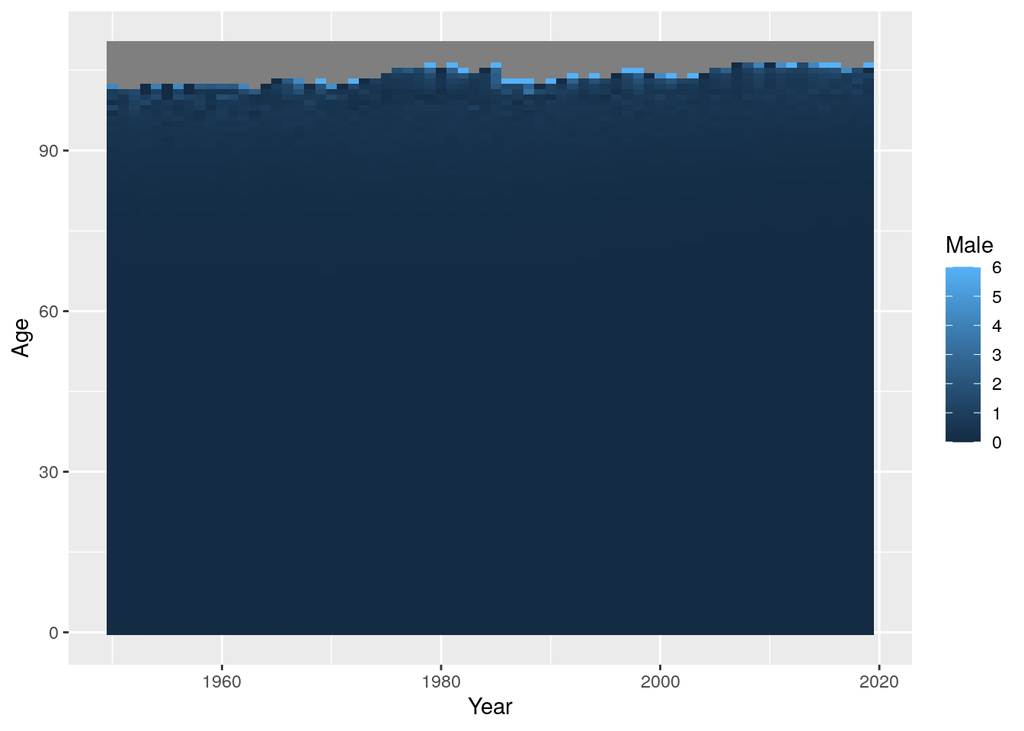

```r
MX %>%
  ggplot(aes(x = Year, y = Age, fill = Male)) +
  geom_tile()
```

We’ll have to modify the plot quite a bit to get a signal out of it. Namely, these empirical $m(x)$ values can get well over 1 in the highest ages, so they drown out the variation below. You could do `log(Male)` and that’d help some, but the breaks wouldn’t be good. One thing at a time. First we’ll be explicit about color choices.

## Choose a color palette

Use a sequential palette for absolute or log quantities plotted on the surface. Note the name of the palette you want

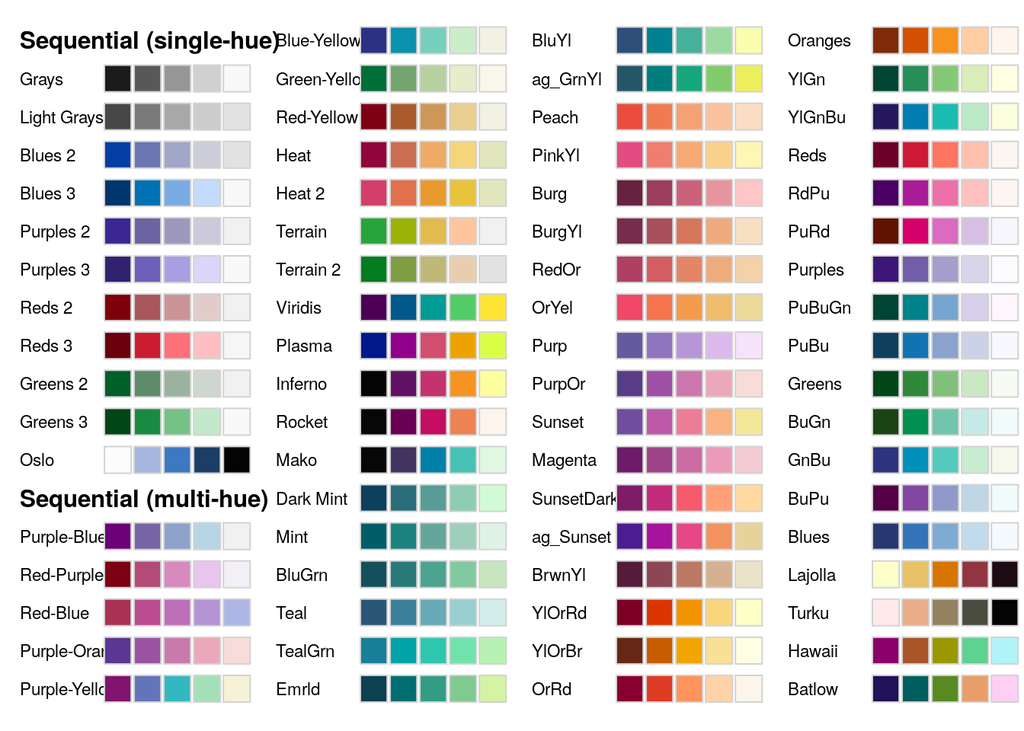

```r
library(colorspace)
hcl_palettes(type = "sequential",plot = TRUE)
```

Use a divergent palette for log rate ratios, or differences, usually it makes sense to choose a neutral color (ratio = 1 or difference = 0) that matches your background…

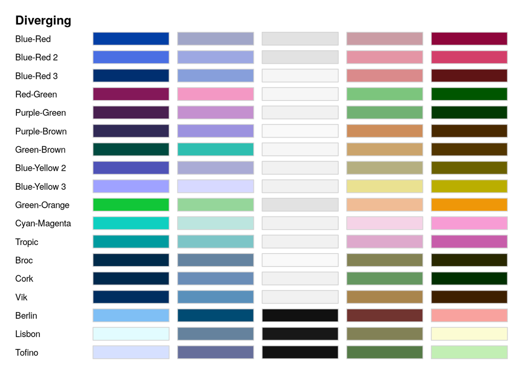

```r
hcl_palettes(type = "diverging",plot = TRUE)
```

This palette system plays nicely together with `ggplot2`. `scale_fill_continuous_sequential()` applies the selected sequential palette.

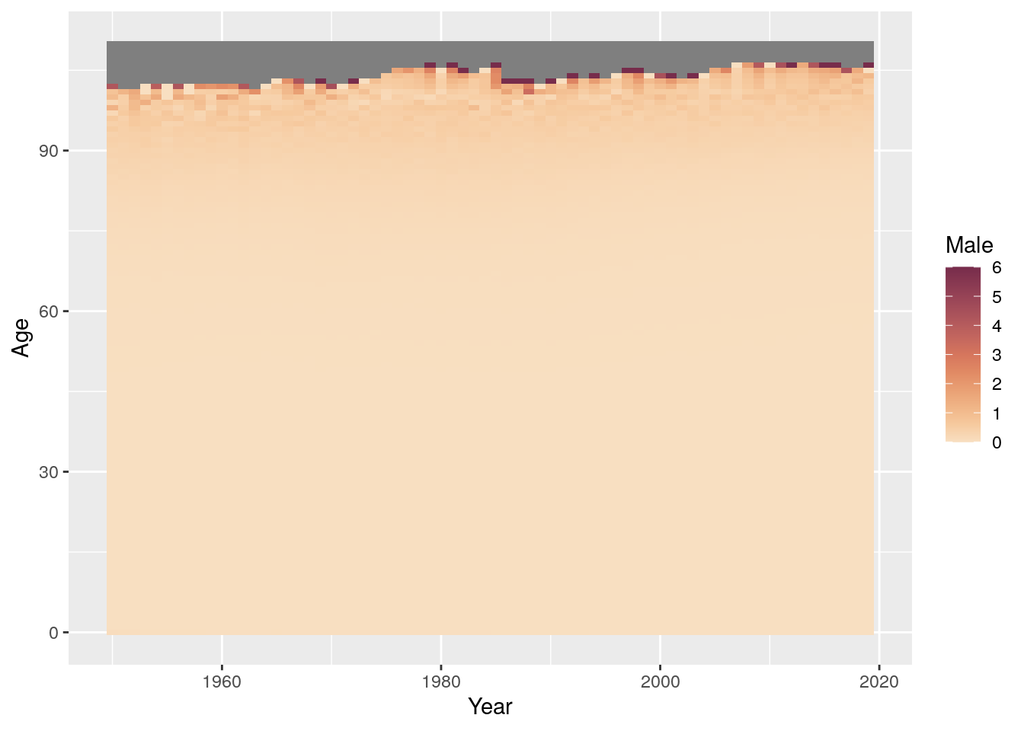

```r
MX %>%
  ggplot(aes(x = Year, y = Age, fill = Male)) +
  geom_tile() +
  scale_fill_continuous_sequential(palette = "BurgYl")
```

And get a good color signal but bad breaks by logging:

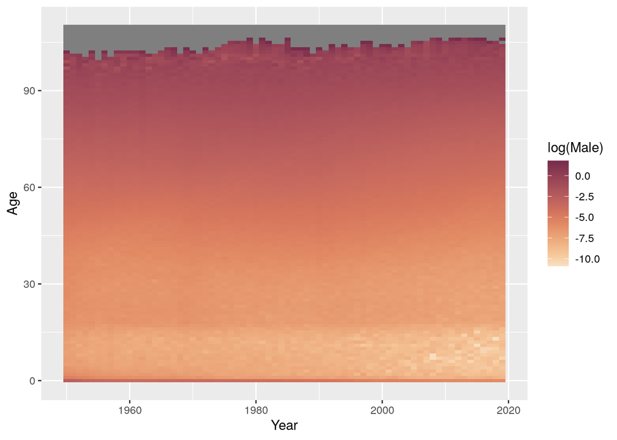

```r
MX %>%
  ggplot(aes(x = Year, y = Age, fill = log(Male))) +
  geom_tile() +
  scale_fill_continuous_sequential(palette = "BurgYl")
```

Here the breaks apply to the logged values, and we don’t really have an intuitive sense of what $e^{-2.5}$ is. So we can instead feed a palette to `scale_gradientn()`. We feed a vector of colors, picking out our palette using `sequential_hcl(palette = "BurgYl",n=10)`, which gets the colors backwards, hence the `%>% rev()` statement. Finally, we tell it to pick breaks that play well with log base ten.

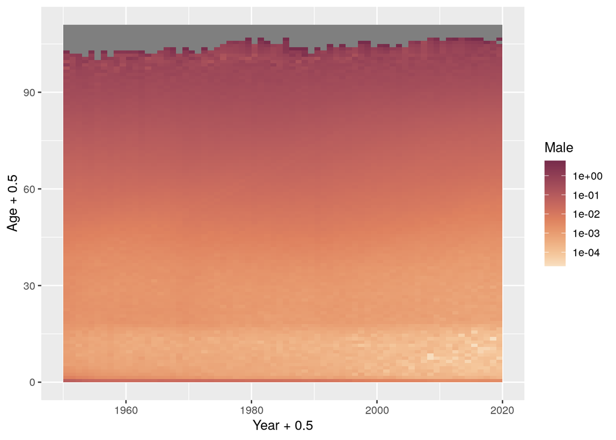

```r
MX %>%
  ggplot(aes(x = Year + .5,
             y = Age + .5,
             fill = Male)) +
  geom_tile() +
  scale_fill_gradientn(colors = sequential_hcl(palette = "BurgYl", n = 10) %>% rev(),
                       trans = "log10")
```

And again, making the scientific notation go away. This result is good enough for me. For something more custom you’d need to specify a manual vector of labels. Let’s not waste more time on it now.

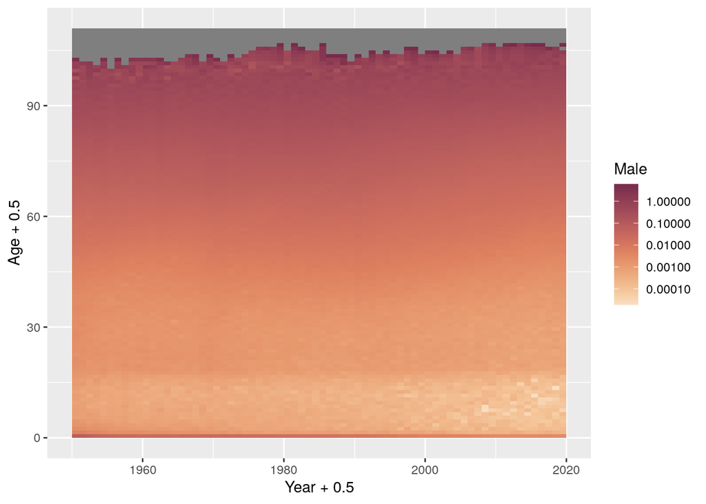

```r
library(scales)
MX %>%
  ggplot(aes(x = Year + .5,
             y = Age + .5,
             fill = Male)) +
  geom_tile() +
  scale_fill_gradientn(colors = sequential_hcl(palette = "BurgYl",n=10) %>% rev(),
                       trans= "log10",
                       labels = comma)
```

## Center Lexis cells

Now let’s enforce an equal aspect ration (one year is one age) on the surface, and manage a detail to ensure the squares are centered. To do this, we add $1/2$ an interval to each year and age. Here it’s an easy half because we’re in single age data, but further thought might be require to center data in other bins.

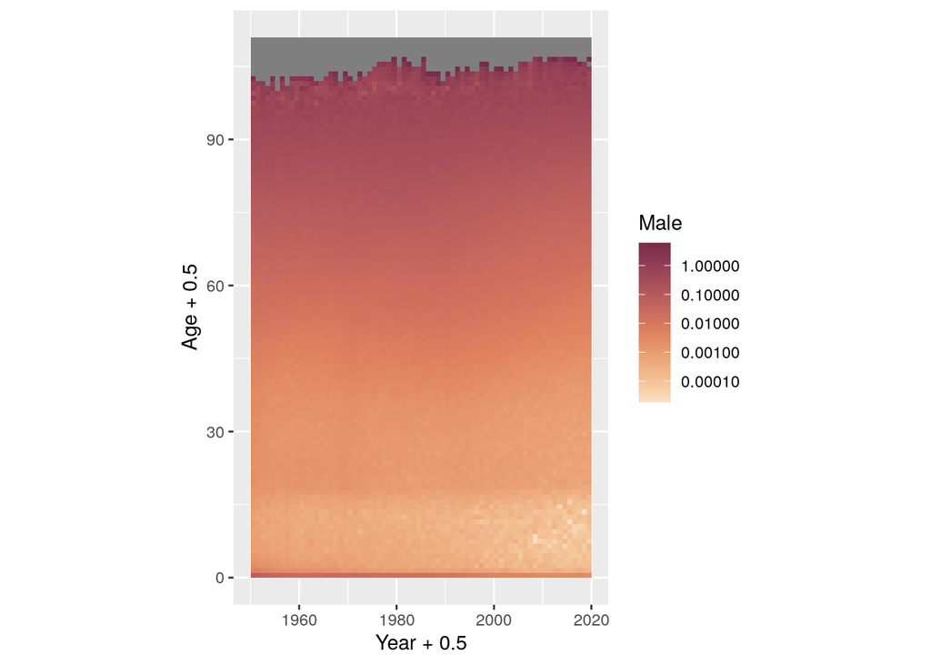

```r
yrs <- MX$Year %>% range()

MX %>%
  ggplot(aes(x = Year + .5,
             y = Age + .5,
             z = Male,
             fill = Male)) +
  geom_tile() +
  scale_fill_gradientn(colors = sequential_hcl(palette = "BurgYl", n = 10) %>% rev(),
                       trans= "log10",
                       labels = comma)+
  coord_equal() +
  xlim(yrs[1],yrs[2] + 1) +
  ylim(0,111)
```

## Add contours

Adding contours can enhance pattern detection for this sort of gradual smooth surface. We’ll feed a slightly different vector of breaks to get more definition.

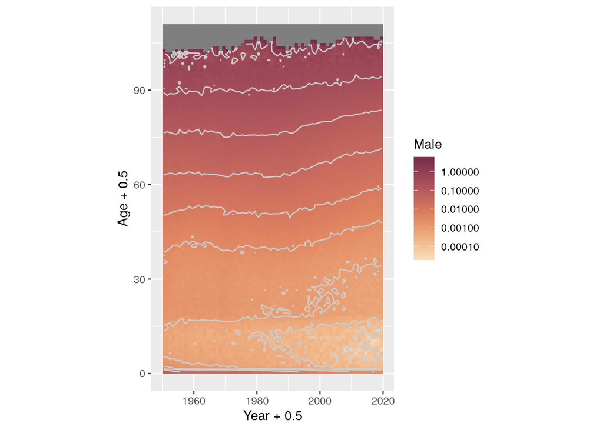

```r
my_breaks = 10^seq(0,-7,by = -.5)

MX %>%
  ggplot(aes(x = Year + .5,
             y = Age + .5,
             z = Male,
             fill = Male)) +
  geom_tile() +
  geom_contour(breaks = my_breaks, color = gray(.8), alpha = 50, size = .5) +
  scale_fill_gradientn(colors = sequential_hcl(palette = "BurgYl", n = 10) %>% rev(),
                       trans = "log10",
                       labels = comma)+
  coord_equal() +
  xlim(yrs[1],yrs[2] + 1) +
  ylim(0,111)
```

## More details

Finally let’s get rid of the gray background, and clean up axis labels

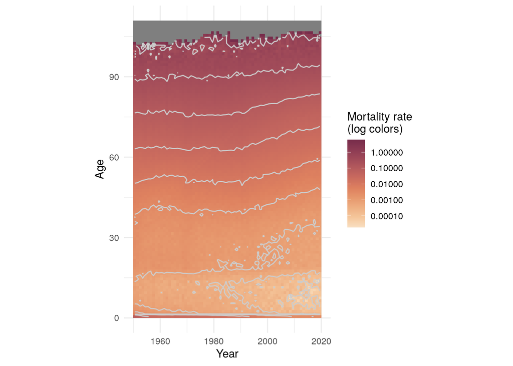

```r
MX %>%
  ggplot(aes(x = Year + .5,
             y = Age + .5,
             z = Male,
             fill = Male)) +
  geom_tile() +
  geom_contour(breaks = my_breaks, color = gray(.8), alpha = 50, size = .5) +
  scale_fill_gradientn(colors = sequential_hcl(palette = "BurgYl", n = 10) %>% rev(),
                       trans = "log10",
                       labels = comma)+
  coord_equal() +
  xlim(yrs[1],yrs[2] + 1) +
  ylim(0,111) +
  xlab("Year") +
  ylab("Age") +
  theme_minimal()+
  labs(fill="Mortality rate\n(log colors)")
```

# Diverging Lexis plot

Say we want to make a plot of residuals, differences, or ratios (logged, say). The only thing that changes is picking out a divergent palette. Here I’ll calculate year-on-year within-age changes in $ln(m(x))$.

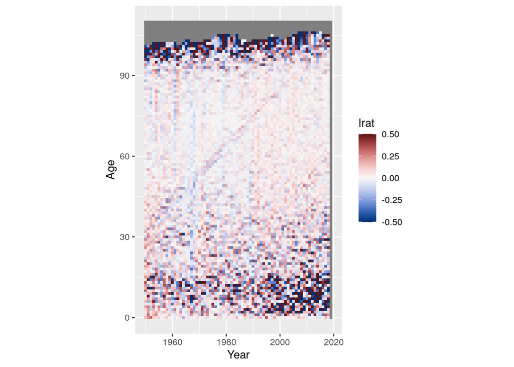

```r
# shift back before joining
MX2 <-
  MX %>%
  mutate(Year = Year - 1,
         mx_previous = Male) %>%
  select(Year, Age, mx_previous)

MX %>%
  mutate(mx_now = Male) %>%
  select(Year, Age, mx_now) %>%
  left_join(MX2, by = c("Year","Age")) %>%
  mutate(lrat = log(mx_now / mx_previous),
         lrat = case_when(lrat < -.5 ~ -.5,
                           lrat > .5 ~ .5,
                           TRUE ~ lrat)) %>%
  ggplot(aes(x = Year, y = Age, fill = lrat)) +
  geom_tile() +
  scale_fill_continuous_diverging("Blue-Red3")+
  coord_equal()
```

Sex ratios are also a good Lexis surface diagnostic sometimes

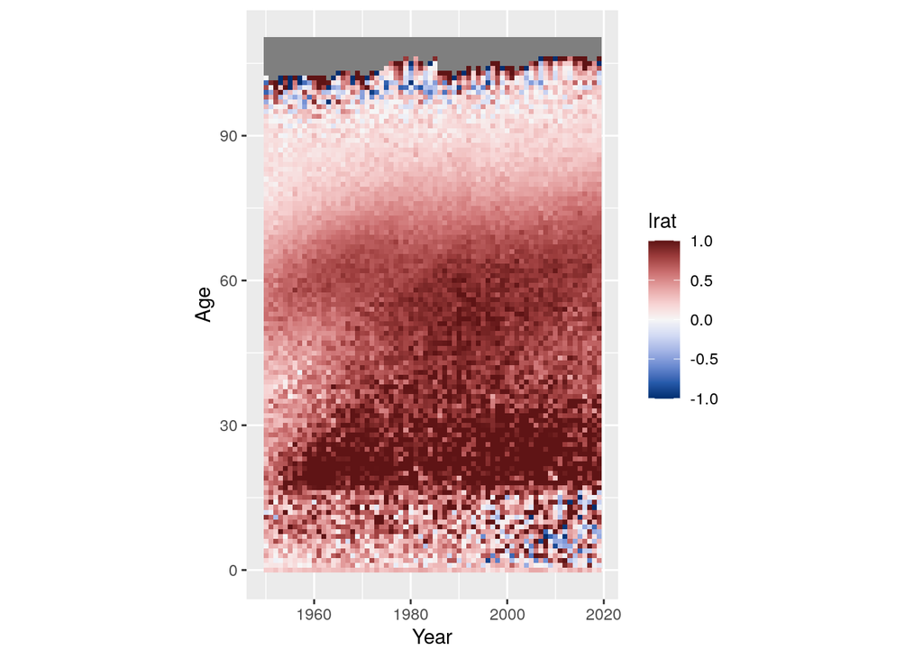

```r
MX %>%
  mutate(lrat = log(Male / Female),
         lrat = case_when(lrat < -1 ~ -1,
                           lrat > 1 ~ 1,
                           TRUE ~ lrat)) %>%
  ggplot(aes(x = Year, y = Age, fill = lrat)) +
  geom_tile() +
  scale_fill_continuous_diverging("Blue-Red3") +
  coord_equal()
```